# Practical 2: Demand monitoring, part I

## part a - out of stock products

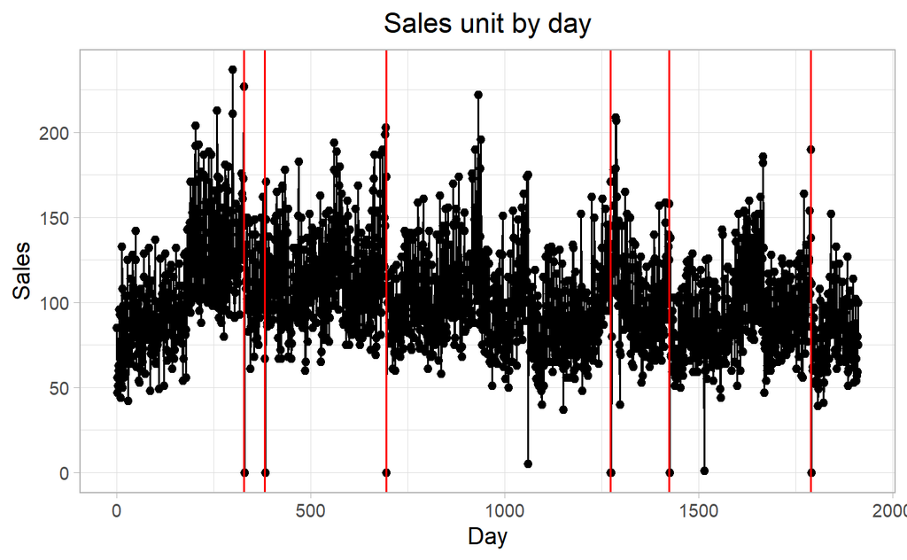

The red line shows when the observed number of sales goes to zero, essentially the extreme of the sales, there are also other instances where it nears to zero however we ignore them for simplicity sake. We run of stock in these cases.

From the graph above, we can also notice that right before going out of stock, the sales are extremely high. When looking at the first block, from day 0 to day 330 which is the first stockout, the sales data are distributes as follows:

Sales Data

[output not shown]

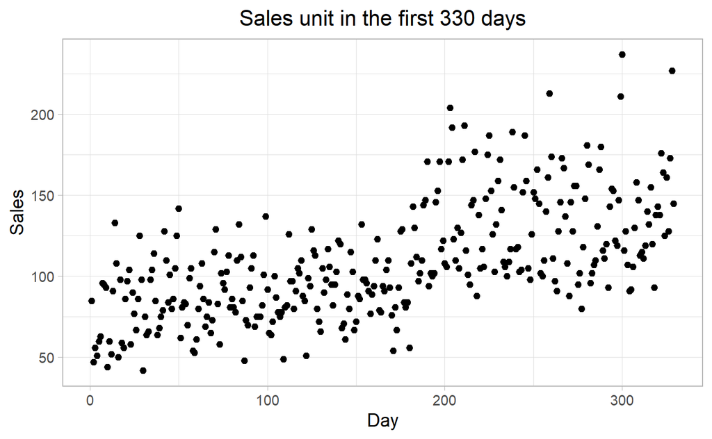

One can clearly notice that there is a positive tren in the sales, which the vendors were not able to forecast hence the stockout at Day 330.

We can now look at what happened between the first and the second stockout.

[output not shown]

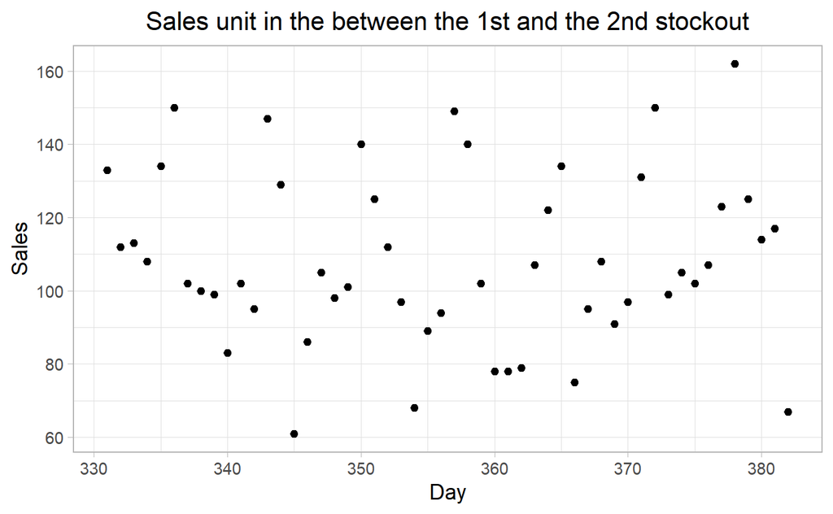

One can notice that following the first stockout there isn’t a particular structure in the sales data, it looks like the sales are random. Moreover, the stockout lasted 2 days. Hence, we can say that the second stockout is probably due to mismanagement following the initial positive trend of the data.

We can now observe what the sales data between day second and thrid time they went out of stock:

[output not shown]

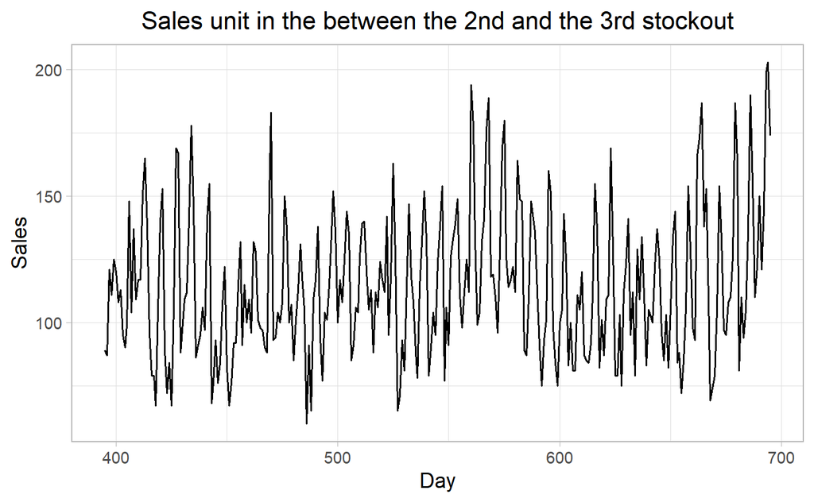

Looking at the sales data distribution in the above graph, one can notice that n the one hand the Sales demand until Day 600 seems kind of linear, but on the other hand following this day it looks like there is once again a positive trend.

Going over each block of data is not necessary as the observations above are already conclusive: the vendors go out of stock when there is an increasing demand. The sellers were probably not able to forecast the positive trends and to manage the inventory given the increasing sales, leading them to stockout.

## part b - newsvendor model

Newsvendor model.

Knowing the newsvendor model we can easily compute p:

```
#> [1] 0.909
```

Alternatively, we could have used the [Scperf](https://cran.r-project.org/web/packages/SCperf/SCperf.pdf) library and the `Newsboy` function.

```
#>      Q     SS   ExpC   ExpP     CV     CR     FR      z
#> 142.04  41.24  50.03 857.21   0.31   0.91   0.99   1.34
```

## part c - critical fractile and Value at Risk

Value-at-Risk (VaR) also known as chance constraint is used in the newsvendor model as a constraint, limiting the probability of particular event (in this case stock-out) happening. In fact, we can say that the critical fractile of the newsvendor model is the equivalent the level of the Value-at-Risk (0.91): we don’t want to go beyond this value to avoid entering the extreme values.

Expected shortfall or conditional or sometimes called conditional value-at-risk , is about ‘how bad can things get?’. More concrectly, one could compute the Value-at-Risk at a level of 0.91, and compute the expected shortfall which indicates the average value of sales when we enter the extremes of the distribution, hence when the sales are extremely high which, as we saw in the beginning of this analysis, is likely to lead to a stockout.

## part d - model using the poisson distribution

Poisson model.

using maximum likelihood estimation for μ.

```
#> [1] 0.91
```

Using the proposed function, we can fit the Poisson model to our data an compute the estimated μ by using the MLE.

After having fitted a Poisson to our data, we obtain μ = 100.8. This allows us to compute the critical fractile: according to this model, the estimated critical fractile is 114.

## part e - peaks-over-thresholds model

We are now going to compute a POT model. First we have to define the threshold.

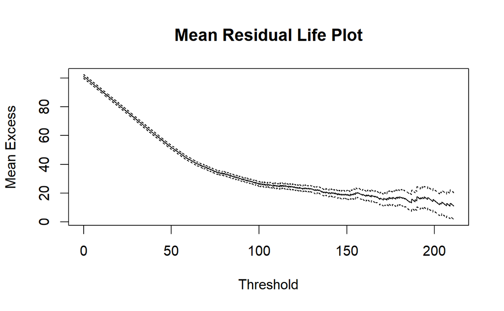

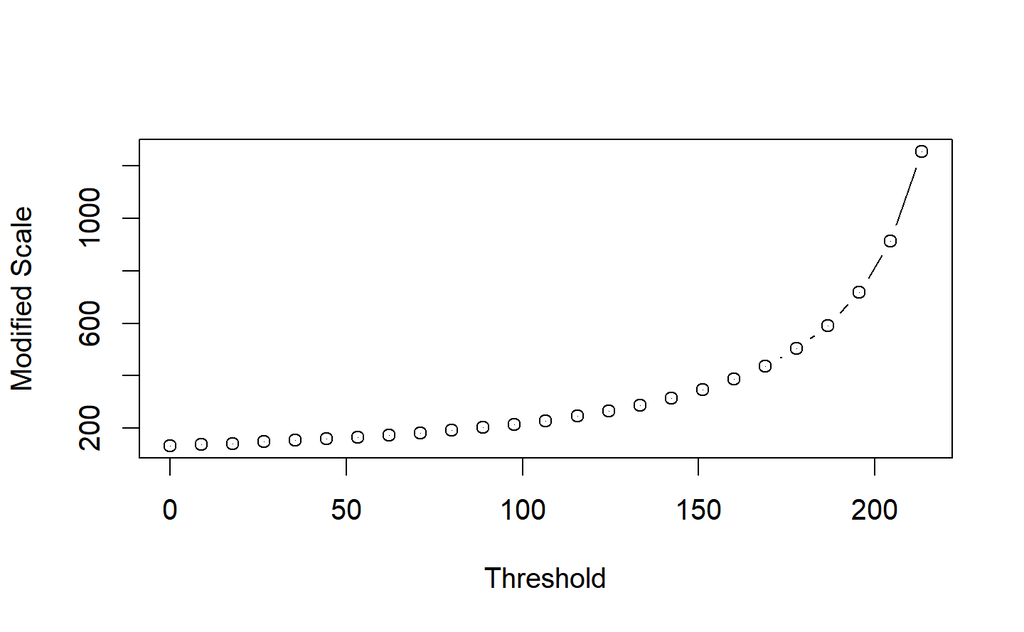

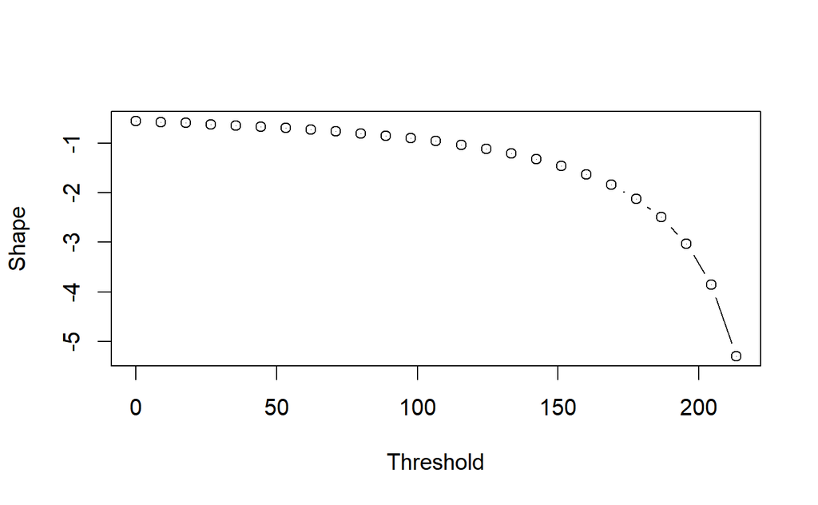

Thresholds of 150 and 170 seem interesting, we can test for both.

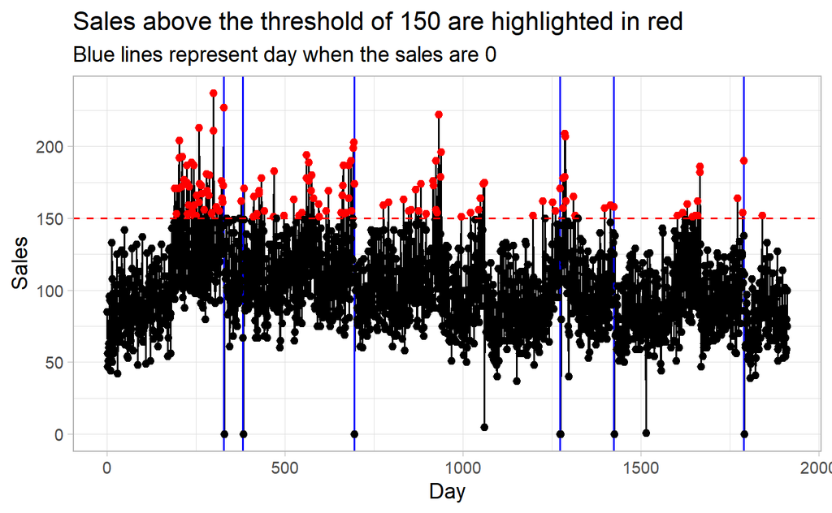

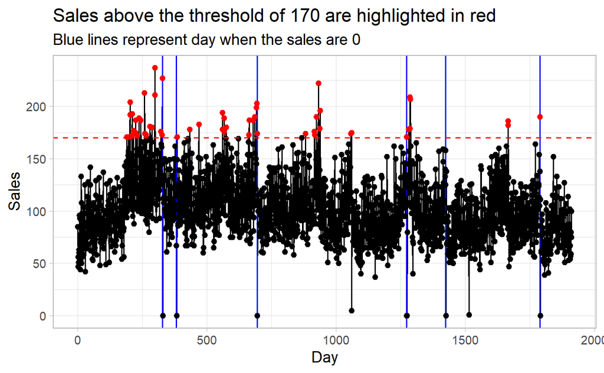

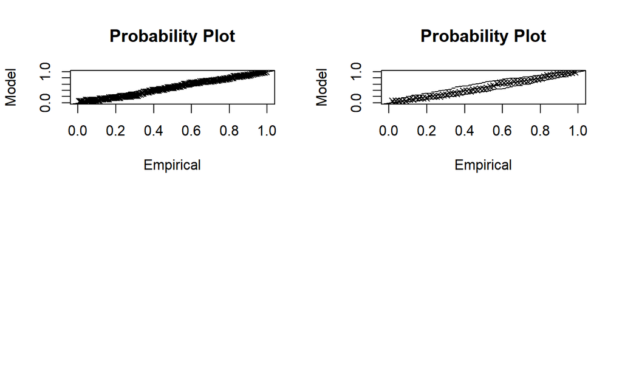

Comparing the pp-plots of the two models, we decide to use the threshold of 150 as it provides better results. Thus, we will use the model with this threshold to compute the Value at Risk.

```
#> [1] 145
```

## part f - binomial backtesting

Back test as seen on the slides. We will go over this in more detail.

### e

```
#>
#>  Exact binomial test
#>
#> data:  sales_violations and nrow(sales_test)
#> number of successes = 15, number of trials = 300, p-value =
#> 0.01
#> alternative hypothesis: true probability of success is not equal to 0.091
#> 95 percent confidence interval:
#>  0.028 0.081
#> sample estimates:
#> probability of success
#>                   0.05
```

We can also do use the 90th of the data for the threshold.

```
#>
#>  1-sample proportions test with continuity correction
#>
#> data:  (nrow(sales_test) - sales_violations) out of nrow(sales_test), null probability cf_news
#> X-squared = 0.9, df = 1, p-value = 0.3
#> alternative hypothesis: true p is not equal to 0.91
#> 95 percent confidence interval:
#>  0.89 0.95
#> sample estimates:
#>    p
#> 0.93
#>
#>  1-sample proportions test with continuity correction
#>
#> data:  sales_violations out of nrow(sales_test), null probability 1 - cf_news
#> X-squared = 0.9, df = 1, p-value = 0.3
#> alternative hypothesis: true p is not equal to 0.091
#> 95 percent confidence interval:
#>  0.048 0.110
#> sample estimates:
#>     p
#> 0.073
#>
#>  Exact binomial test
#>
#> data:  sales_violations and nrow(sales_test)
#> number of successes = 22, number of trials = 300, p-value =
#> 0.4
#> alternative hypothesis: true probability of success is not equal to 0.091
#> 95 percent confidence interval:
#>  0.047 0.109
#> sample estimates:
#> probability of success
#>                  0.073
```